# Probability and Statistics

# - Naive Bayes Classifier -

### *Andrii Namasnyi, Anastasiia Senyk, Fedir Zhurba*

## Introduction

During the past three weeks, you learned a couple of essential notions and theorems, and one of the most important among them is the *Bayes theorem*.

One of its applications is **Naive Bayes classifier**, which is a probabilistic classifier whose aim is to determine which class some observation probably belongs to by using the Bayes formula:
$$\mathsf{P}(\mathrm{class}\mid
\mathrm{observation})=\frac{\mathsf{P}(\mathrm{observation}\mid\mathrm{class})\mathsf{P}(\mathrm{class})}{\mathsf{P}(\mathrm{observation})}$$

Under the strong independence assumption, one can calculate $\mathsf{P}(\mathrm{observation} \mid \mathrm{class})$ as
$$\mathsf{P}(\mathrm{observation}) =
\prod_{i=1}^{n} \mathsf{P}(\mathrm{feature}_i), \qquad
\mathsf{P}(\mathrm{observation} \mid \mathrm{class}) = \prod_{i=1}^{n}
\mathsf{P}(\mathrm{feature}_i \mid \mathrm{class}),$$
where $n$ is the total number of features describing a given observation. Thus, $\mathsf{P}(\mathrm{class}|\mathrm{observation})$ now can be calculated as

$$\mathsf{P}(\mathrm{class} \mid
\mathrm{\mathrm{observation}}) = \mathsf{P}(\mathrm{class})\times
\prod_{i=1}^{n}\frac{\mathsf{P}(\mathrm{feature}_i\mid
\mathrm{class})}{\mathsf{P}(\mathrm{feature}_i)}\tag{1}$$

All the terms on the right-hand side can be estimated from the data as respective relative frequencies;  
see [this site](https://monkeylearn.com/blog/practical-explanation-naive-bayes-classifier/) for more detailed explanations.

## Data description

There is a dataset.

- **fake news** This data set contains data of American news: a headline and an abstract of the article. Each piece of news is classified as fake or credible. The task is to classify the news from test.csv as credible or fake.

The data set consists of two files: *train.csv* and *test.csv*. The first one we need to find the probabilities distributions for each of the features, while the second one is needed for checking how well your classifier works.

```r
# here goes a list of recommended libraries,
# though you may install other ones if they are needed
library(tidytext)
library(readr)
library(ggplot2)
library(tokenizers)
```

### Data pre-processing

- Read the *.csv* data files.
- Сlear your data from punctuation or other unneeded symbols.
- Clear you data from stop words. You don’t want words as is, and, or etc. to affect your probabilities distributions, so it is a wise decision to get rid of them. Find list of stop words in the cms under the lab task.
- Represent each test message as its bag-of-words.

## Classifier implementation

```r
naiveBayes <- setRefClass("naiveBayes",

                          # here it would be wise to have some vars to store intermediate result
                          # frequency dict etc. Though pay attention to bag of wards!
                          fields = list(
                            credible_probs = "table",
                            fake_probs = "table",
                            credible_news = "data.frame",
                            fake_news = "data.frame",
                            p_credible = "table",
                            p_fake = "table"

                          ),




                          methods = list(

                            tokens_conditional_prob = function(tokens) {
                              occurrences <- table(unlist(tokens)) + 1
                              return (occurrences / sum(occurrences))
                            },




                            # prepare your training data as X - bag of words for each of your
                            # messages and corresponding label for the message encoded as 0 or 1
                            # (binary classification task)
                            fit_data = function(dataf, splitted_stop_words)
                            {
                              dataf$text <- paste(dataf$Headline,dataf$Body, sep = " ")
                              dataf$text <- tokenize_words(dataf$text, lowercase = TRUE, strip_numeric = TRUE, strip_punct = TRUE, stopwords = splitted_stop_words)


                              credible_news <<- subset(dataf, Label == 'credible')
                              fake_news <<- subset(dataf, Label == 'fake')

                              credible_probs <<- tokens_conditional_prob(credible_news$text)
                              fake_probs <<- tokens_conditional_prob(fake_news$text)


                              p_credible <<- table(credible_news$Label) / sum(table(dataf$Label))
                              p_fake <<- table(fake_news$Label) / sum(table(dataf$Label))

                              return (dataf)
                            },




                            fit_test = function(dataf, splitted_stop_words)
                            {
                              dataf$text <- paste(dataf$Headline, dataf$Body, sep = " ")
                              dataf$text <- tokenize_words(dataf$text, lowercase = TRUE, strip_numeric = TRUE, strip_punct = TRUE, stopwords = splitted_stop_words)

                              return (dataf)

                            },




                            # return prediction for a single message
                            predict_for_dataf = function(dataf)
                            {


                              dataf$res <- NA
                              index = 1

                              for (news in dataf$text) {
                                dataf[index, 6] = predict(news)
                                index = index + 1
                              }

                              dataf <- dataf[c('Headline', 'Body', 'Label', 'res')]
                              return (dataf)

                            },




                            predict = function(news)
                            {
                              credible_guess = p_credible
                              fake_guess = p_fake
                              res = 1

                              for (word in unlist(news)) {
                                credible_word <- credible_probs[word]
                                fake_word <- fake_probs[word]



                                if (!is.na(credible_probs[word]) & !is.na(fake_probs[word])) {
                                  credible_guess = (credible_probs[word] * p_credible) / (credible_probs[word] * p_credible + fake_probs[word] * p_fake)
                                }

                                if (!is.na(fake_probs[word]) & !is.na(credible_probs[word])) {
                                  fake_guess = (fake_probs[word] * p_fake) / (credible_probs[word] * p_credible + fake_probs[word] * p_fake)
                                }


                                res = res * (credible_guess / fake_guess)
                              }

                              if (res > 1) {
                                return ('credible')
                              }
                              return ('fake')
                              },





                            # score you test set so to get the understanding how well you model
                            # works.
                            # look at f1 score or precision and recall
                            # visualize them
                            # try how well your model generalizes to real world data!
                            score = function(test)
                            {
                              tp = sum(table(which(test$Label == 'credible' & test$res == 'credible')))
                              fp = sum(table(which(test$Label == 'fake' & test$res == 'credible')))
                              fn = sum(table(which(test$Label == 'credible' & test$res == 'fake')))
                              precision = tp / (tp + fp)

                              recall = tp / (tp + fn)

                              f1score = 2 * (precision * recall) / (recall + precision)

                              return (f1score)
                            },


                            score_visual = function(dataf)
                            {
                                true_positive = table(dataf$res=="credible" & dataf$Label=="credible")["TRUE"]
                                true_negative = table(dataf$res=="fake" & dataf$Label=="fake")["TRUE"]
                                false_negative = table(dataf$res=="fake" & dataf$Label=="credible")["TRUE"]
                                false_positive = table(dataf$res=="credible" & dataf$Label=="fake")["TRUE"]
                                slices <- c(true_positive, true_negative, false_positive, false_negative)
                                lbls <- c("True Positive", "True Negative", "False Positive", "False Negative")
                                pct <- round(slices/sum(slices)*100)
                                lbls <- paste(lbls, pct)
                                lbls <- paste(lbls,"%",sep="")
                                pie(slices, labels = lbls, col=rainbow(length(lbls)), main="Prediction accuracy")
                            }

                          )
)
```

### Main function

To get the result, we use the Naive Bayes Classifier. To implement it, we parse our messages into words and then calculate a conditional probability of each word appearing in credible and fake news separately. Then we use Bayes’ theorem to calculate the conditional probability that news is credible given words in the header and body.

```r
main_f <- function(test_path, train_path, stop_words_path){

  test <- read.csv(test_path, stringsAsFactors = FALSE)
  data <- read.csv(train_path, stringsAsFactors = FALSE)
  stop_words <- read_file(stop_words_path)
  splitted_stop_words <- strsplit(stop_words, split='\n')[[1]]


  model = naiveBayes()
  data <- model$fit_data(data, splitted_stop_words)
  test <- model$fit_test(test, splitted_stop_words)

  test <- model$predict_for_dataf(test);

  print('score - >')
  print(model$score(test))
  print(model$score_visual(test))

  return (test)
}
```

```r
stop_words_path <- "/Users/anastasiaa/Documents/UCU/P_S/Lab1/stop_words.txt"
test_path <- "/Users/anastasiaa/Documents/UCU/P_S/Lab1/data/2-fake_news/test.csv"
train_path <- "/Users/anastasiaa/Documents/UCU/P_S/Lab1/data/2-fake_news/train.csv"

test <- main_f(test_path, train_path, stop_words_path)
```

```
## [1] "score - >"
## [1] 0.9451023
```

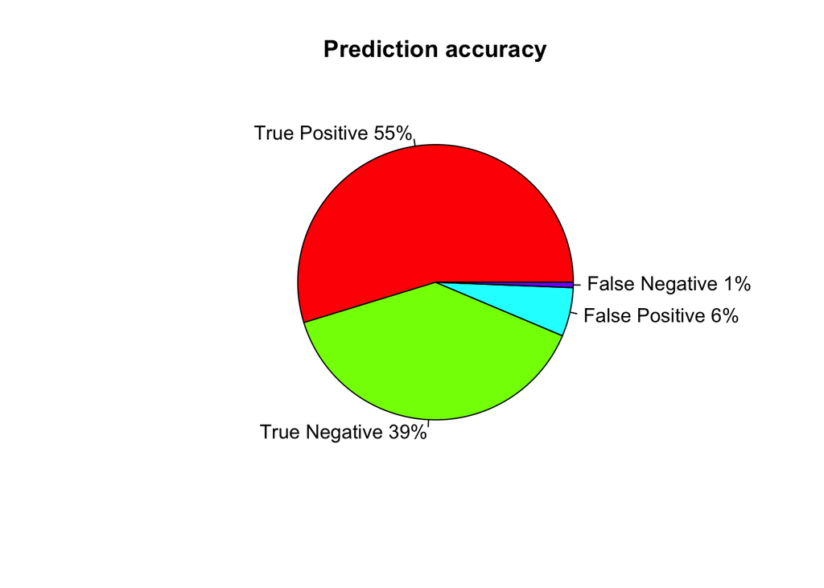

## Conclusions

### Pros and Cons

The main advantage of this approach is its high efficiency and speed. It is also quite understandable and intuitive. Also, it is quite easy to train. But this method has huge disadvantages, it is built in “perfect world” conditions. So, if we work with real data, we face that data is somehow biased and variables are not fully independent. However, this method remains quite accurate. Also, this method does not take into account the order of words. However, it can be really valuable for our data. What is more, we assume that the header and body have the same value, but in fact header or body can be more important in our model.